# Job research about data scientists

Haoran Su

12/13/2020

# Introduction

This project is about utilizing text mining in R. Since we are going to find a job of data scientist or statistical job, it is important for us to know about what features the interviewers are looking for. Data is crawled from Indeed website that is for job listings.(indeed link: https://www.indeed.com/)

Here I mainly focus on the following 3 questions:

1.How many job opportunities area there for data scientists and statistical analysists?

2.What skills do the positions require?

3.Are there any similarities and differences between the descriptions of jobs in two different areas?

## Data crawled

Here is a script from the data crawled.

| title | company | location | summary |
| --- | --- | --- | --- |
| Data Analyst | Global Technical Talent | Boston, MA | Proficiency with data warehouse, data mining, data analysis, and predictive modeling. |
| Data Scientist Intern | Homesite Insurance | Boston, MA | Analyze text, voice and/or image (unstructured data) analytics. |
| Data Scientist | Harvard University | Boston, MA | 00 - Non Union, Exempt or Temporary. |
| Part-Time Virtual Call Center Sales Agent | APG | Boston, MA | Enter data into the system accurately. |
| Data Scientist | Amazon Dev Center U.S., Inc. | Boston, MA | Or statistical/mathematical software (e.g. R, SAS, or Matlab). |

# Job Distribution

## List the top 10 states with the most job positions of data scientists

The plot shows that MA has the most positions of data scientists, which is not a display of the whole job listing.The reason of having Masachussette ranking 1st might for the location of crawling is at Boston, MA. So my analysis will turn to analysis the job opportunities near my current coordinate.

| state | area | count |
| --- | --- | --- |
| MA | Boston | 44 |
| MA | Cambridge | 30 |
| NY | New York | 11 |
| CA | San Francisco | 4 |
| MA | Quincy | 3 |
| MA | Somerville | 3 |

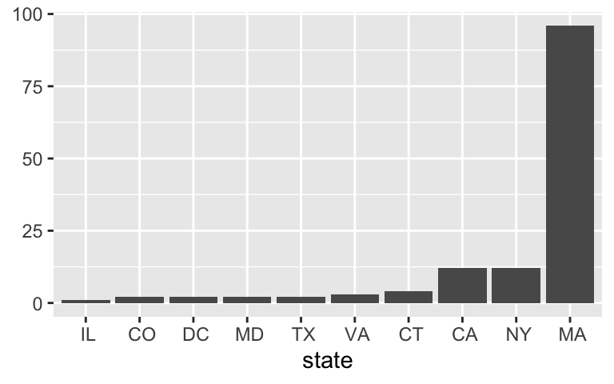

## List the top 10 companies with the most job positions of data scientists

| company | count |
| --- | --- |
| CVS Health | 5 |
| Biogen | 3 |
| Harvard University | 3 |
| Microsoft | 3 |
| InsideTracker | 2 |
| LanceSoft Inc | 2 |

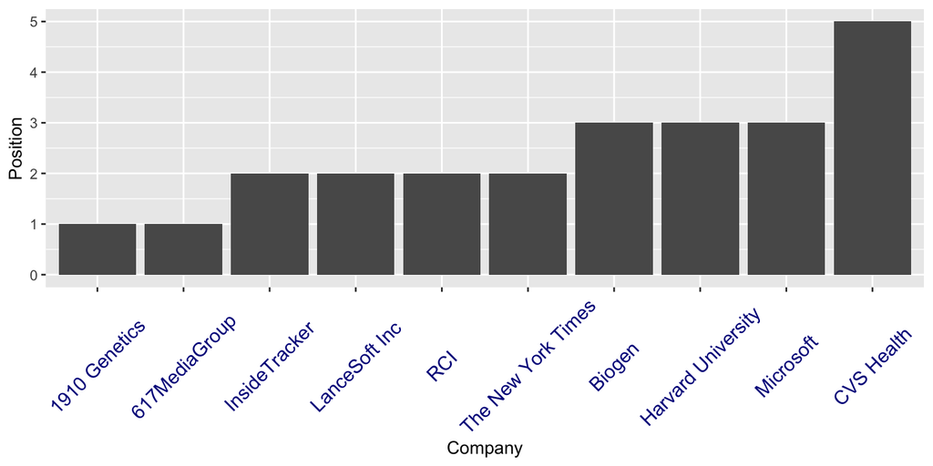

# Word frequency in Description

Looking at the description of jobs, I want to know “what skills do the positions require”.

## Word Cloud

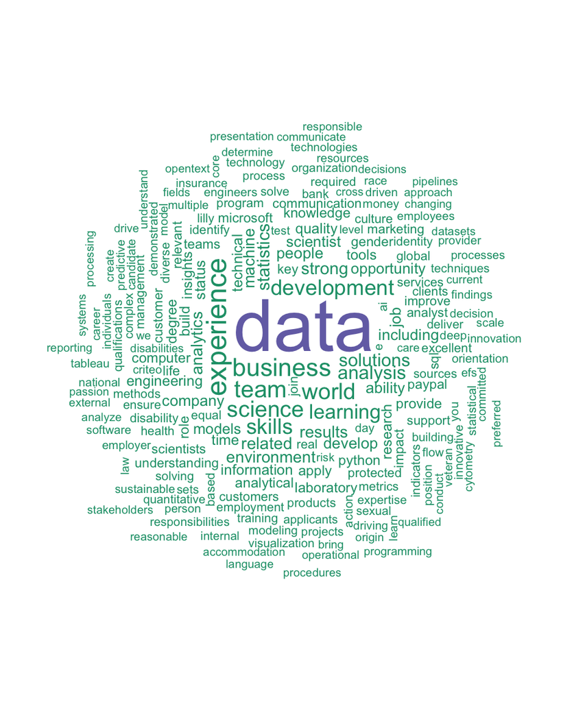

## The most 10 common words in description

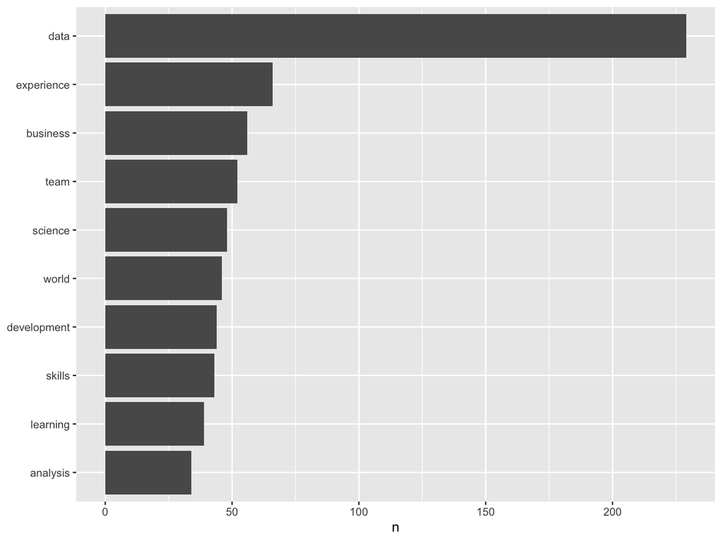

# Words appear together

Some words may come together. The following plot shows common bigrams of words, showing those that occurred more than 3 times and where neither word was a stop word.

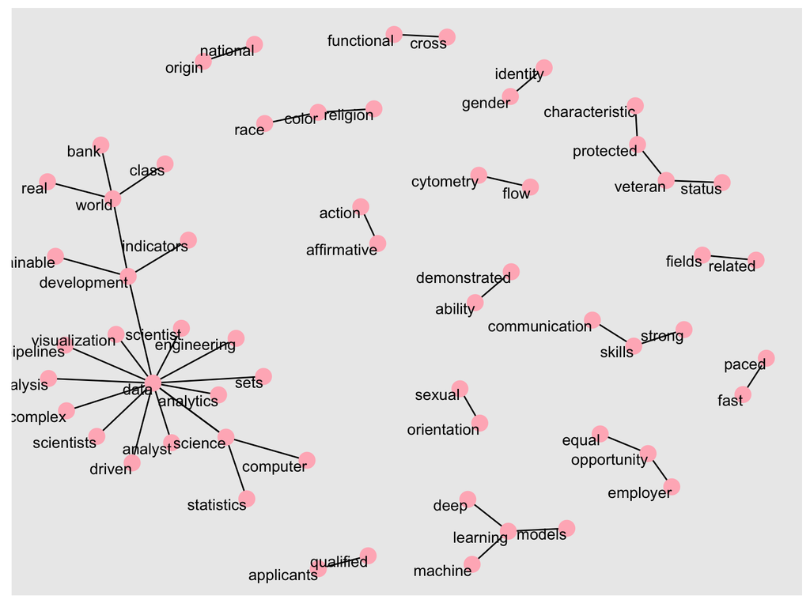

# The descriptions of jobs in two different areas

As my location is at Boston, I want to look at the job descriptions of the areas nearby. The plot shows the comparison the word frequencies of Boston, Cambridge and Framingham.

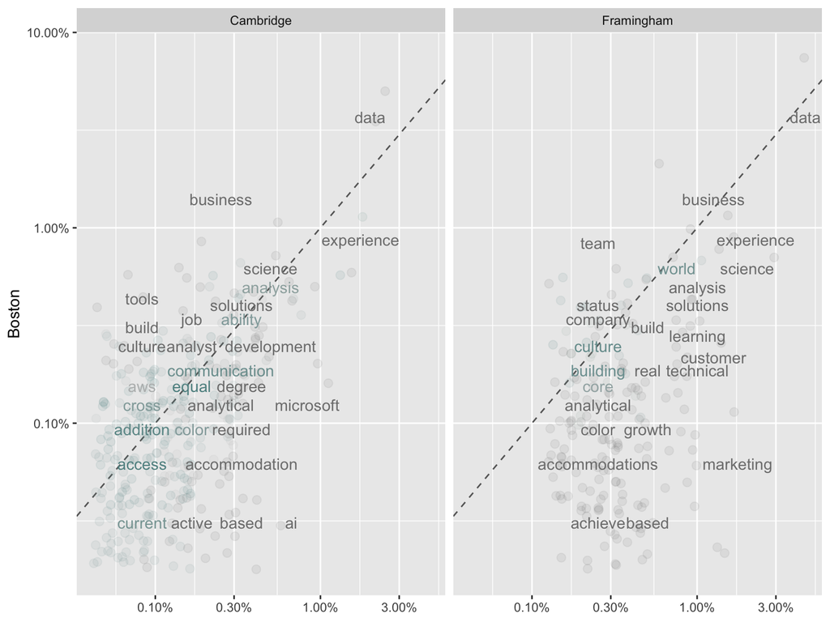